# 26_unit_circ_float

## 26_unit_circ_float

#### Question

1. An angle, $\theta$, is shown below in standard position as a blue spiraling arrow. A radius (of length 1) is drawn at that angle. Where the radius connects to the circumference of the unit circle has Cartesian coordinates $(0.609, -0.793)$.

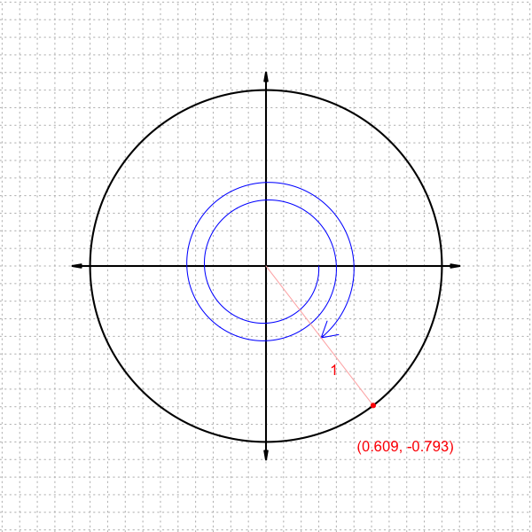

   Calculate the trigonometric ratios of $\theta$.
   - The sine: $\sin(\theta) =$
   - The cosine: $\cos(\theta)=$
   - The tangent: $\tan(\theta)=$

#### Question

2. An angle, $\theta$, is shown below in standard position as a blue spiraling arrow. A radius (of length 1) is drawn at that angle. Where the radius connects to the circumference of the unit circle has Cartesian coordinates $(-0.821, -0.571)$.

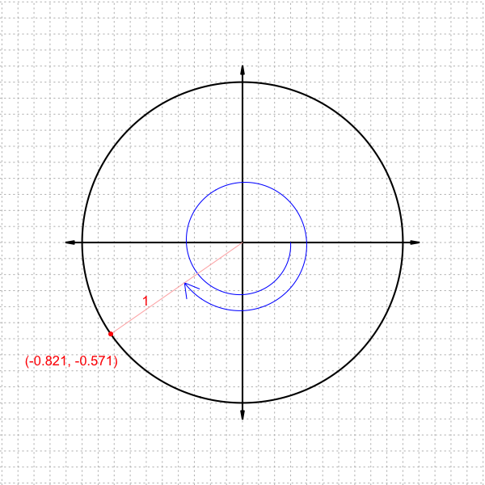

   Calculate the trigonometric ratios of $\theta$.
   - The sine: $\sin(\theta) =$
   - The cosine: $\cos(\theta)=$
   - The tangent: $\tan(\theta)=$

#### Question

3. An angle, $\theta$, is shown below in standard position as a blue spiraling arrow. A radius (of length 1) is drawn at that angle. Where the radius connects to the circumference of the unit circle has Cartesian coordinates $(0.768, 0.641)$.

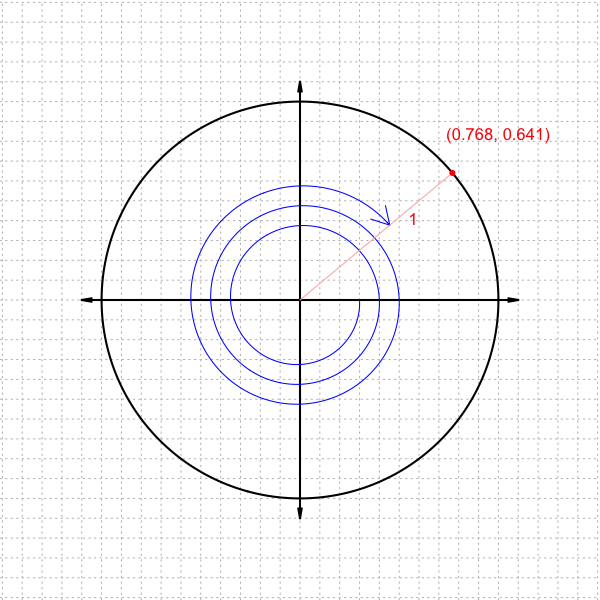

   Calculate the trigonometric ratios of $\theta$.
   - The sine: $\sin(\theta) =$
   - The cosine: $\cos(\theta)=$
   - The tangent: $\tan(\theta)=$

#### Question

4. An angle, $\theta$, is shown below in standard position as a blue spiraling arrow. A radius (of length 1) is drawn at that angle. Where the radius connects to the circumference of the unit circle has Cartesian coordinates $(-0.851, -0.525)$.

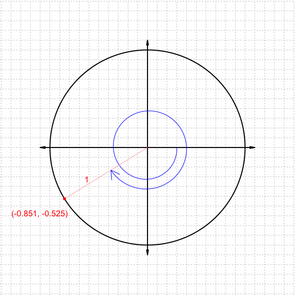

   Calculate the trigonometric ratios of $\theta$.
   - The sine: $\sin(\theta) =$
   - The cosine: $\cos(\theta)=$
   - The tangent: $\tan(\theta)=$

#### Question

5. An angle, $\theta$, is shown below in standard position as a blue spiraling arrow. A radius (of length 1) is drawn at that angle. Where the radius connects to the circumference of the unit circle has Cartesian coordinates $(-0.918, 0.396)$.

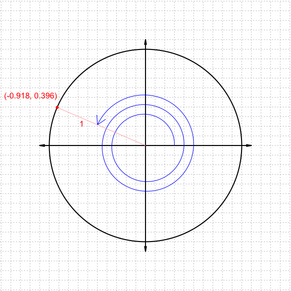

   Calculate the trigonometric ratios of $\theta$.
   - The sine: $\sin(\theta) =$
   - The cosine: $\cos(\theta)=$
   - The tangent: $\tan(\theta)=$

#### Question

6. An angle, $\theta$, is shown below in standard position as a blue spiraling arrow. A radius (of length 1) is drawn at that angle. Where the radius connects to the circumference of the unit circle has Cartesian coordinates $(0.682, 0.731)$.

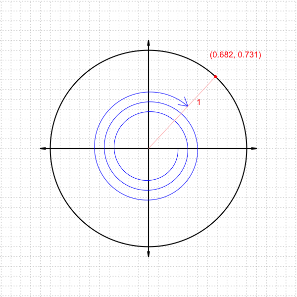

   Calculate the trigonometric ratios of $\theta$.
   - The sine: $\sin(\theta) =$
   - The cosine: $\cos(\theta)=$
   - The tangent: $\tan(\theta)=$

#### Question

7. An angle, $\theta$, is shown below in standard position as a blue spiraling arrow. A radius (of length 1) is drawn at that angle. Where the radius connects to the circumference of the unit circle has Cartesian coordinates $(-0.329, -0.944)$.

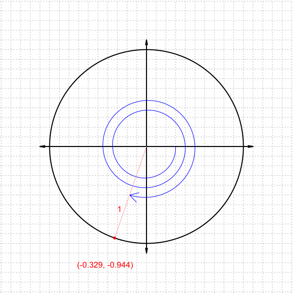

   Calculate the trigonometric ratios of $\theta$.
   - The sine: $\sin(\theta) =$
   - The cosine: $\cos(\theta)=$
   - The tangent: $\tan(\theta)=$

#### Question

8. An angle, $\theta$, is shown below in standard position as a blue spiraling arrow. A radius (of length 1) is drawn at that angle. Where the radius connects to the circumference of the unit circle has Cartesian coordinates $(-0.563, 0.826)$.

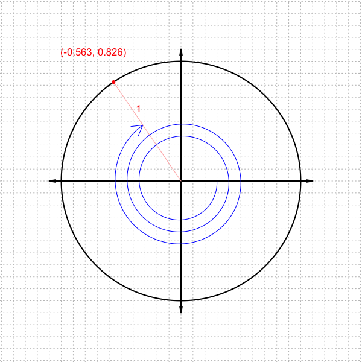

   Calculate the trigonometric ratios of $\theta$.
   - The sine: $\sin(\theta) =$
   - The cosine: $\cos(\theta)=$
   - The tangent: $\tan(\theta)=$